# 01 — Distribution Shifts

# 4. Percentile Trajectory (Signature Visual)

The 10th/25th/50th/75th/90th percentile of `distance` each year. This is the most direct way to answer the core question: if the 90th percentile line rises faster than the 10th, the elite are pulling away; if the 10th rises faster, the competitive floor is catching up; if the bands stay a constant width while the whole fan shifts up, the increase is uniform across the field.

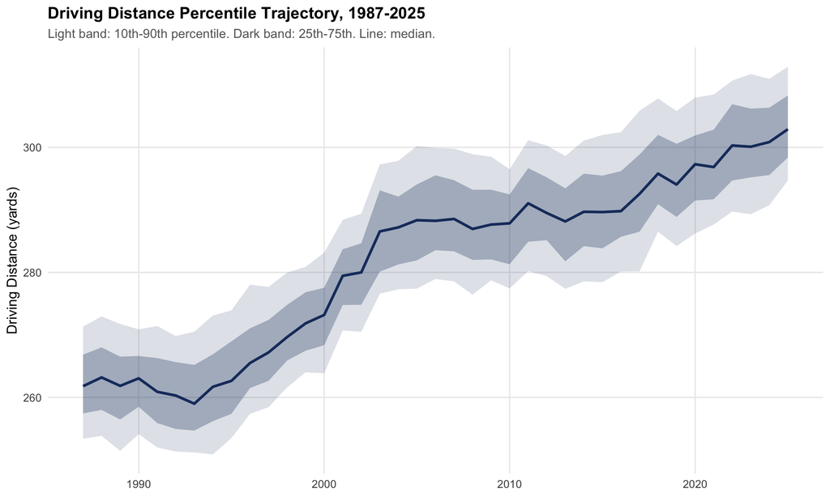

```r
percentile_trend <- df_trends %>%
  group_by(year) %>%
  summarise(
    p10 = quantile(distance, 0.10, na.rm = TRUE),
    p25 = quantile(distance, 0.25, na.rm = TRUE),
    p50 = quantile(distance, 0.50, na.rm = TRUE),
    p75 = quantile(distance, 0.75, na.rm = TRUE),
    p90 = quantile(distance, 0.90, na.rm = TRUE),
    .groups = "drop"
  )

p_fan <- ggplot(percentile_trend, aes(year)) +
  geom_ribbon(aes(ymin = p10, ymax = p90), fill = COL_PRIMARY, alpha = 0.15) +
  geom_ribbon(aes(ymin = p25, ymax = p75), fill = COL_PRIMARY, alpha = 0.30) +
  geom_line(aes(y = p50), color = COL_PRIMARY, linewidth = 1.1) +
  labs(
    title    = "Driving Distance Percentile Trajectory, 1987-2025",
    subtitle = "Light band: 10th-90th percentile. Dark band: 25th-75th. Line: median.",
    x = NULL, y = "Driving Distance (yards)"
  ) +
  THEME_BASE

p_fan
```

```r
pt <- percentile_trend %>% arrange(year) %>% mutate(band = p90 - p10, gain3 = p50 - lag(p50, 3))
sharpest <- pt %>% filter(!is.na(gain3)) %>% slice_max(gain3, n = 1)

band_first <- pt %>% filter(year == min(year)) %>% pull(band)
band_last  <- pt %>% filter(year == max(year)) %>% pull(band)
```

**Finding:** the sharpest multi-year move in the whole series is centered on 2003 — median distance gained 13.4 yards in the 3 years ending then (the Pro V1 / COR-limit transition, 2000-2003), the steepest stretch anywhere in the data. The 10th-90th percentile band widened during that same transition before narrowing back down; by 2025 it’s 18.2 yards wide versus 17.9 in 1987 — essentially the same width, consistent with section 3’s near-flat CV: this reads as a broad shift that temporarily stretched the field during the equipment transition, not a steady widening gap between short and long hitters.

# 5. Quantile Regression Over Time

The fan chart shows *what* happened to each percentile; quantile regression quantifies *how fast*. We fit `distance ~ year` separately at each quantile (`tau`) using `quantreg::rq()` on the full player-year data (not the pre-aggregated yearly percentiles from section 4), which lets each quantile’s slope reflect the underlying data directly rather than a trend fit to five summary points. Standard errors use the `"nid"` (non-i.i.d.) approximation rather than bootstrapping — appropriate here given the sample size per year (~180-195) and much faster to compute; the point is spotting whether upper and lower quantiles diverge, not thousandth-yard precision.

```r
quantile_slopes <- map_dfr(c(0.10, 0.25, 0.50, 0.75, 0.90), function(q) {
  fit <- rq(distance ~ year, tau = q, data = df_trends)
  s   <- summary(fit, se = "nid")
  tibble(
    tau   = q,
    slope = coef(fit)[["year"]],
    se    = s$coefficients["year", "Std. Error"]
  )
})

quantile_slopes %>% print()
```

```
## # A tibble: 5 × 3
##     tau slope     se
##   <dbl> <dbl>  <dbl>
## 1  0.1   1.18 0.0163
## 2  0.25  1.19 0.0117
## 3  0.5   1.18 0.0118
## 4  0.75  1.20 0.0137
## 5  0.9   1.20 0.0180
```

**Interpretation:** a bigger `slope` at `tau = 0.90` than `tau = 0.10` means the longest hitters are gaining yards faster than the shortest hitters — i.e. the elite pulling away, not a uniform shift.

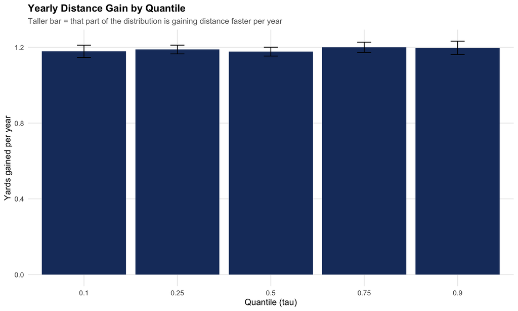

```r
p_slopes <- ggplot(quantile_slopes, aes(factor(tau), slope)) +
  geom_col(fill = COL_PRIMARY) +
  geom_errorbar(aes(ymin = slope - 1.96 * se, ymax = slope + 1.96 * se), width = 0.15) +
  labs(
    title    = "Yearly Distance Gain by Quantile",
    subtitle = "Taller bar = that part of the distribution is gaining distance faster per year",
    x = "Quantile (tau)", y = "Yards gained per year"
  ) +
  THEME_BASE

p_slopes
```

```r
slope_range <- range(quantile_slopes$slope)
```

# 6. Wasserstein Distance From a Reference Year

The Wasserstein (earth-mover’s) distance measures how much “work” it would take to reshape one year’s whole distribution into another’s — capturing shifts in shape, not just central tendency. We use 1990 as the baseline (early enough to represent the “old” era, but with a full, non-sparse sample — every year from 1987 on has ~180-195 players, so this isn’t a small-sample artifact).

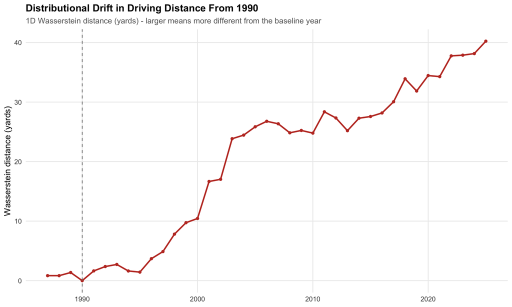

```r
REFERENCE_YEAR <- 1990

reference_dist <- df_trends %>%
  filter(year == REFERENCE_YEAR) %>%
  pull(distance)

wasserstein_by_year <- df_trends %>%
  group_by(year) %>%
  summarise(
    wasserstein_dist = transport::wasserstein1d(distance, reference_dist),
    .groups = "drop"
  )

p_wasserstein <- ggplot(wasserstein_by_year, aes(year, wasserstein_dist)) +
  geom_line(color = COL_ACCENT, linewidth = 1) +
  geom_point(color = COL_ACCENT) +
  geom_vline(xintercept = REFERENCE_YEAR, linetype = "dashed", color = "grey50") +
  labs(
    title    = paste("Distributional Drift in Driving Distance From", REFERENCE_YEAR),
    subtitle = "1D Wasserstein distance (yards) - larger means more different from the baseline year",
    x = NULL, y = "Wasserstein distance (yards)"
  ) +
  THEME_BASE

p_wasserstein
```

```r
w_2025 <- wasserstein_by_year %>% filter(year == max(year)) %>% pull(wasserstein_dist)
w_peak_year <- wasserstein_by_year %>% filter(wasserstein_dist == max(wasserstein_dist)) %>% pull(year)
```

**Finding:** drift from the 1990 baseline grows almost monotonically, reaching 40.2 yards of Wasserstein distance by 2025 (the largest in the series, at 2025) — the distribution keeps moving further from its 1990 shape rather than plateauing or reverting, echoing the steady rise already visible in the fan chart.

# 7. Distance-Accuracy Trade-off

Is hitting the ball farther still associated with hitting it less accurately, and has that trade-off strengthened or weakened over time? We use Spearman (rank) correlation rather than Pearson because we care about the *relationship* between relative standing on each metric, not the linear scale of the raw values.

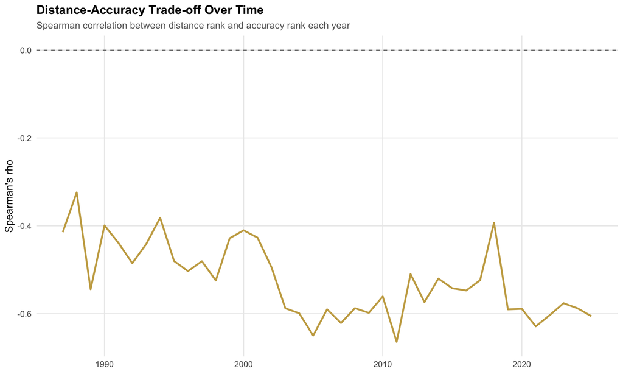

```r
spearman_by_year <- df_trends %>%
  group_by(year) %>%
  summarise(
    rho = cor(distance, accuracy, method = "spearman", use = "complete.obs"),
    .groups = "drop"
  )

p_spearman <- ggplot(spearman_by_year, aes(year, rho)) +
  geom_line(color = COL_SECONDARY, linewidth = 1) +
  geom_hline(yintercept = 0, linetype = "dashed", color = "grey50") +
  labs(
    title    = "Distance-Accuracy Trade-off Over Time",
    subtitle = "Spearman correlation between distance rank and accuracy rank each year",
    x = NULL, y = "Spearman's rho"
  ) +
  THEME_BASE

p_spearman
```

```r
rho_first <- spearman_by_year %>% filter(year == min(year)) %>% pull(rho)
rho_last  <- spearman_by_year %>% filter(year == max(year)) %>% pull(rho)
rho_early_avg <- spearman_by_year %>% filter(year <= min(year) + 9) %>% summarise(m = mean(rho)) %>% pull(m)
rho_late_avg  <- spearman_by_year %>% filter(year >= max(year) - 9) %>% summarise(m = mean(rho)) %>% pull(m)
```

**Finding:** the trade-off has *strengthened*, not weakened — Spearman’s rho moved from -0.41 in 1987 to -0.61 in 2025 (decade averages: -0.44 in the first 10 years vs. -0.56 in the most recent 10). Longer hitters today give up relatively more accuracy than longer hitters did in the late 1980s — distance gains haven’t come for free.

## 7.1 Scatter triptych: three eras

Three representative years spanning the dataset, to see the trade-off directly rather than through a single summary statistic.

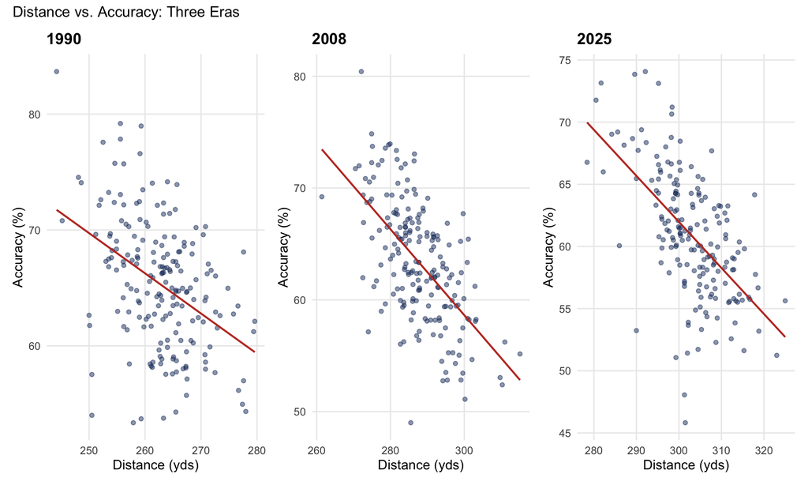

```r
triptych_years <- c(1990, 2008, 2025)

triptych_plots <- map(triptych_years, function(yr) {
  df_trends %>%
    filter(year == yr) %>%
    ggplot(aes(distance, accuracy)) +
    geom_point(alpha = 0.5, color = COL_PRIMARY) +
    geom_smooth(method = "lm", se = FALSE, color = COL_ACCENT, linewidth = 0.8) +
    labs(title = as.character(yr), x = "Distance (yds)", y = "Accuracy (%)") +
    THEME_BASE
})

wrap_plots(triptych_plots, nrow = 1) +
  plot_annotation(title = "Distance vs. Accuracy: Three Eras")
```

**Finding:** the downward-sloping fitted line visibly steepens from 1990 to 2025, a direct visual confirmation of the strengthening trade-off quantified above.

# 8. Ridgeline Plot

A distributional complement to the fan chart in section 4 — every 5th year, plus 2025 to include the most recent season.

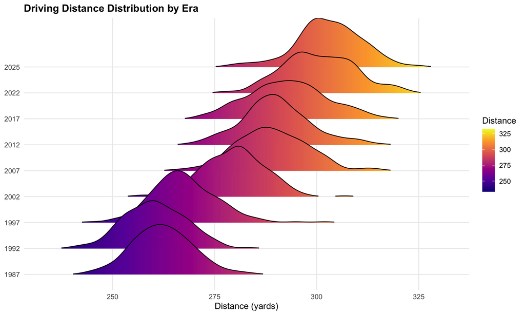

```r
ridge_years <- seq(1987, 2025, by = 5)
if (!2025 %in% ridge_years) ridge_years <- c(ridge_years, 2025)

p_ridge <- df_trends %>%
  filter(year %in% ridge_years) %>%
  ggplot(aes(x = distance, y = factor(year), fill = after_stat(x))) +
  geom_density_ridges_gradient(scale = 2, rel_min_height = 0.01) +
  scale_fill_viridis_c(name = "Distance", option = "C") +
  labs(
    title = "Driving Distance Distribution by Era",
    x = "Distance (yards)", y = NULL
  ) +
  THEME_BASE +
  theme(legend.position = "right")

p_ridge
```

**Finding:** the ridges shift steadily right with each successive era and show the same pattern as the fan chart — a fairly clean rightward slide rather than one ridge developing a visibly different shape (extra bumps, elongated tails) from its neighbors. The most visible “jump” between adjacent ridges is 1997→2002, consistent with the 2000-2003 transition already identified in section 4.

# 9. Speed-Era Distributional Trends (`df_main`)

The sections above show *that* distance increased and *how* it was distributed. This section checks whether the metrics behind the distance gain — carry distance, ball speed, clubhead speed (CHS) — moved the same way, using `df_main` filtered to `year >= SPEED_ERA_START`. We reuse the `SPEED_ERA_START` constant from `config.R` (2007) rather than hardcoding it, since it’s already the documented cutoff for when these metrics became reliable (see `00_data_engineering.Rmd` section 3.2 — 2004-2006 rows are NA). This is a different source dataset from sections 2-8 (`df_main`, not `df_trends`), so results aren’t directly overlaid until section 10, where we put everything on a common index.

```r
df_main <- readRDS(here(PATH_PROCESSED, "df_main.rds"))

df_speed <- df_main %>%
  filter(year >= SPEED_ERA_START)

cat("Rows (", SPEED_ERA_START, "-2025):", nrow(df_speed), "\n")
```

```
## Rows ( 2007 -2025): 3581
```

```r
cat("Unique players:                  ", n_distinct(df_speed$player_name), "\n")
```

```
## Unique players:                   705
```

## 9.1 Per-year mean and CV

```r
speed_yearly_stats <- df_speed %>%
  group_by(year) %>%
  summarise(
    across(
      c(carry_distance, ball_speed, chs),
      list(mean = ~mean(.x, na.rm = TRUE), cv = ~sd(.x, na.rm = TRUE) / mean(.x, na.rm = TRUE)),
      .names = "{.col}_{.fn}"
    ),
    .groups = "drop"
  )

speed_yearly_stats %>% print(n = 10)
```

```
## # A tibble: 19 × 7
##     year carry_distance_mean carry_distance_cv ball_speed_mean ball_speed_cv
##    <int>               <dbl>             <dbl>           <dbl>         <dbl>
##  1  2007                267.            0.0410            166.        0.0368
##  2  2008                269.            0.0434            166.        0.0367
##  3  2009                269.            0.0430            165.        0.0370
##  4  2010                269.            0.0416            166.        0.0351
##  5  2011                272.            0.0400            167.        0.0350
##  6  2012                276.            0.0408            168.        0.0358
##  7  2013                275.            0.0404            168.        0.0368
##  8  2014                274.            0.0418            168.        0.0360
##  9  2015                277.            0.0407            168.        0.0358
## 10  2016                275.            0.0398            168.        0.0364
## # ℹ 9 more rows
## # ℹ 2 more variables: chs_mean <dbl>, chs_cv <dbl>
```

```r
speed_first <- speed_yearly_stats %>% filter(year == min(year))
speed_last  <- speed_yearly_stats %>% filter(year == max(year))
```

**Finding:** all three rose over 2007-2025: carry distance 266.8 → 287.4 yds (+20.6), ball speed 165.9 → 174.8 mph (+8.9), clubhead speed 112.8 → 116.7 mph (+3.9). Directionally consistent with the overall distance trend, but section 10 checks whether the *rates* of increase actually line up.

## 9.2 Percentile trajectories

A lighter version of section 4’s fan chart (median + IQR band only, not the full 10th-90th treatment) across all three speed-era metrics at once, to keep the notebook focused rather than repeating every section 2-8 analysis three more times.

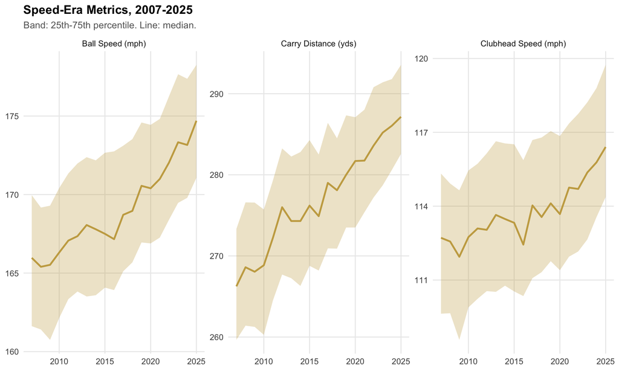

```r
speed_percentiles <- df_speed %>%
  select(year, carry_distance, ball_speed, chs) %>%
  pivot_longer(cols = c(carry_distance, ball_speed, chs), names_to = "metric", values_to = "value") %>%
  group_by(year, metric) %>%
  summarise(
    p25 = quantile(value, 0.25, na.rm = TRUE),
    p50 = quantile(value, 0.50, na.rm = TRUE),
    p75 = quantile(value, 0.75, na.rm = TRUE),
    .groups = "drop"
  )

metric_labels <- c(
  carry_distance = "Carry Distance (yds)",
  ball_speed     = "Ball Speed (mph)",
  chs            = "Clubhead Speed (mph)"
)

p_speed_trends <- ggplot(speed_percentiles, aes(year)) +
  geom_ribbon(aes(ymin = p25, ymax = p75), fill = COL_SECONDARY, alpha = 0.3) +
  geom_line(aes(y = p50), color = COL_SECONDARY, linewidth = 1) +
  facet_wrap(~metric, scales = "free_y", labeller = as_labeller(metric_labels)) +
  labs(
    title    = paste0("Speed-Era Metrics, ", SPEED_ERA_START, "-2025"),
    subtitle = "Band: 25th-75th percentile. Line: median.",
    x = NULL, y = NULL
  ) +
  THEME_BASE

p_speed_trends
```

**Finding:** all three panels trend upward across the window with no sharp break comparable to the 2000-2003 distance/accuracy transition — the strokes-gained era doesn’t cover the equipment-change period, so this section only sees the more gradual, recent phase of the buildup.

# 10. Are Distance, Carry Distance, Ball Speed, and CHS Moving Together?

If all four metrics move in lockstep, that points to a common driver (equipment, athleticism, training). If they diverge — say distance rises faster than ball speed — the distance gain isn’t purely a speed story (e.g. course setup, launch conditions, or measurement changes could be contributing too). We index each metric to its `SPEED_ERA_START` value (each year as a % of the 2007 mean) so metrics on very different natural scales (yards vs. mph) are visually comparable. `distance` is recomputed here from `df_main` over the same 2007-2025 window used for the other three — not the full 1987-2025 range from section 4 — so the comparison is apples-to-apples across a shared time window and data source.

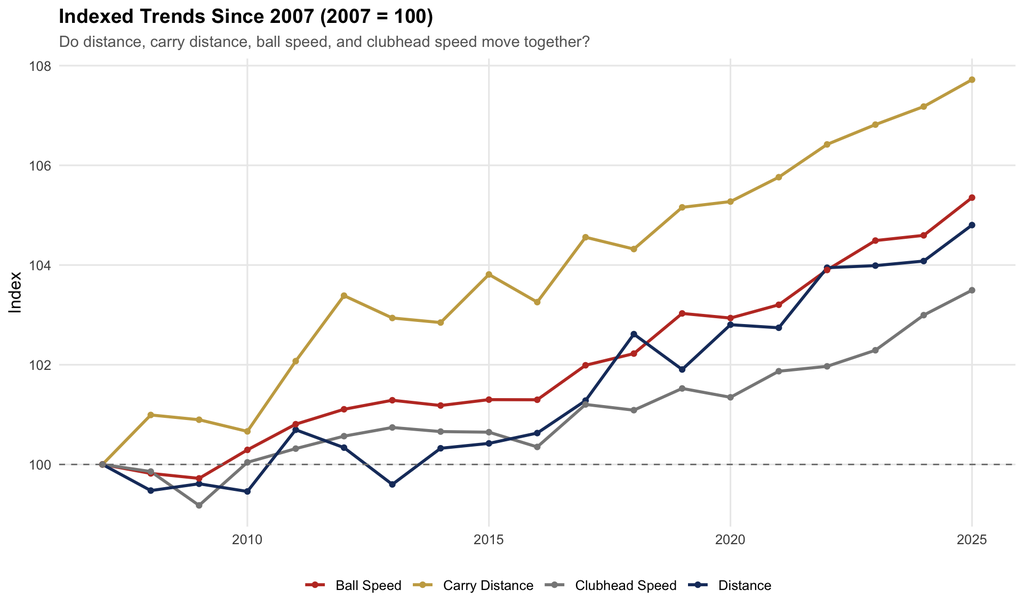

```r
index_base <- df_speed %>%
  filter(year == SPEED_ERA_START) %>%
  summarise(
    distance       = mean(distance, na.rm = TRUE),
    carry_distance = mean(carry_distance, na.rm = TRUE),
    ball_speed     = mean(ball_speed, na.rm = TRUE),
    chs            = mean(chs, na.rm = TRUE)
  )

index_trend <- df_speed %>%
  group_by(year) %>%
  summarise(
    distance       = mean(distance, na.rm = TRUE),
    carry_distance = mean(carry_distance, na.rm = TRUE),
    ball_speed     = mean(ball_speed, na.rm = TRUE),
    chs            = mean(chs, na.rm = TRUE),
    .groups = "drop"
  ) %>%
  mutate(
    distance       = 100 * distance / index_base$distance,
    carry_distance = 100 * carry_distance / index_base$carry_distance,
    ball_speed     = 100 * ball_speed / index_base$ball_speed,
    chs            = 100 * chs / index_base$chs
  ) %>%
  pivot_longer(-year, names_to = "metric", values_to = "index")

metric_series_labels <- c(
  distance = "Distance", carry_distance = "Carry Distance",
  ball_speed = "Ball Speed", chs = "Clubhead Speed"
)

p_index <- ggplot(index_trend, aes(year, index, color = metric)) +
  geom_line(linewidth = 1) +
  geom_point() +
  geom_hline(yintercept = 100, linetype = "dashed", color = "grey50") +
  scale_color_manual(
    values = c(distance = COL_PRIMARY, carry_distance = COL_SECONDARY,
               ball_speed = COL_ACCENT, chs = COL_NEUTRAL),
    labels = metric_series_labels
  ) +
  labs(
    title    = paste0("Indexed Trends Since ", SPEED_ERA_START, " (", SPEED_ERA_START, " = 100)"),
    subtitle = "Do distance, carry distance, ball speed, and clubhead speed move together?",
    x = NULL, y = "Index", color = NULL
  ) +
  THEME_BASE

p_index
```

```r
index_2025 <- index_trend %>% filter(year == max(year))
idx <- setNames(index_2025$index, index_2025$metric)
```

**Finding:** by 2025, carry distance leads at index 107.7, ahead of distance (104.8) and ball speed (105.4), with clubhead speed lagging furthest behind at 103.5. They’re all rising together in broad strokes, but carry distance is pulling ahead of the pure speed metrics — something beyond clubhead speed alone (ball/course conditions, launch optimization) is contributing to the recent carry-distance gain.